# MÁQUINA DE TURING

Teoría de la Computación  
2026-2

Walter Quispe Vargas

wquispev@utec.edu.pe  
Departamento de Ciencia de la Computación, UTEC

# CONTENIDO

- OBJETIVOS
- MÁQUINA DE TURING
  - Definición
  - Diseño
  - Lenguajes Reconocibles
- CONCLUSIONES

# OBJETIVOS

- Conocer y Diseñar una Máquina de Turing
- Definir los Lenguajes que reconoce una Máquina de Turing

## MÁQUINA DE TURING

[figure not shown]

## MÁQUINA DE TURING

- TEORÍA DE LA COMPUTAIÓN
  - AUTÓMATAS ✅
  - COMPUTABILIDAD
  - COMPLEJIDAD
- COMPUTABILIDAD
  - Qué problemas se pueden ser resuletos por una computadora? ALGORITMICA
  - MODELO DE COMPUTACIÓN: Base teórica para entender qué problemas se pueden resolver mediante un algoritmo.
- MÁQUINA DE TURING: Dispositivo teórico abtracto  
  (no es una máquina física)
  - Este dispositivo manipula símbolos sobre una `cinta` infinita siguiendo un conjunto de reglas fijas.
  - Tiene un `cabezal` que se mueve sobre la `cinta`  
    (derecha o izquierda).
  - Puede `leer` y `escribir` símbolos en la `cinta`.
  - Inicialmente la `cinta` contiene la cadena de entrada y un simbolo especial `blanco` por el resto de la `cinta`.
  - Si la máquina necesita almacenar información, `escribe` en la `cinta`.
  - Para `leer` la información `escrita`, la máquina puede mover su `cabezal` hasta encontrarla.
  - La máquina continua el **computo** hasta que decide una salida:
    - *ACEPTA* o *RECHAZA* de acuerdo a sus reglas y estados.
    - Si no, continua y nunca para.

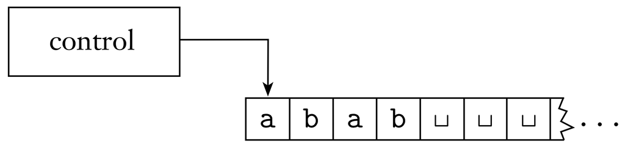

- https://turingmachinesimulator.com

## MÁQUINA DE TURING

- Una **MT** es una 7-tupla $(Q,\Sigma, \Gamma, \delta, q_0, q_a, q_r)$, donde:
  - $Q$ es un conjunto finito de estados,
  - $\Sigma$ es un conjunto finito de símbolos de entrada,
  - $\Gamma$ es un conjunto finito de símbolos de la cinta, donde:
    - **Símbolo Blanco**: $\sqcup \in \Gamma$,
    - $\sqcup \notin \Sigma$,
    - $\Sigma \subseteq \Gamma$,
  - $q_0 \in Q$ es el estado inicial,
  - $q_a \in Q$ es el estado de aceptación,
  - $q_r \in Q$ es el estado de rechazo, donde $q_a\neq q_r$.
    - Los estados especiales de rechazo y aceptación entran en vigor de inmediato.
  - $\delta$ es la función de transición,
    - $\delta: Q \times \Gamma \rightarrow Q \times \Gamma \times \{L,R\}$ ,
    - Donde $L$ y $R$ son los movimientos del cabezal **izquierda** y **derecha** respectivamente,
    - Ejemplo: $\delta(q,a)=(r,b,L)$
      - Cuando la máquina se encuentra en un estado $q$ y el cabezal está sobre una casilla de la cinta que contiene un símbolo $a$…
      - … la máquina **ESCRIBE** el símbolo $b$ (reemplazando la $a$) y **PASA** al estado $r$ y el cabezal se **DESPLAZA** hacia la izquierda $L$.

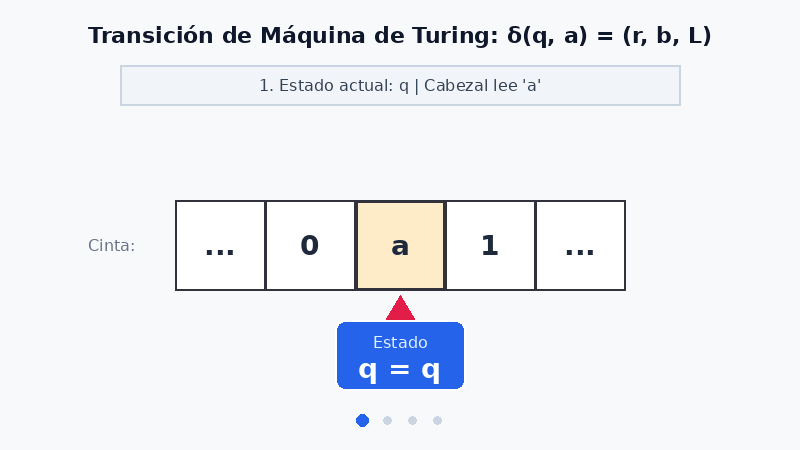

## MÁQUINA DE TURING

- EJEMPLO:
- Consideremos la máquina de Turing $M_1$.  
  Cuál es el proposito de la máquina?
- $Q=\{s_0,s_1,s_2,s_3\}$
- $\Sigma=\{0,1\}$
- $\Gamma = \{0,1,\sqcup\}$
- $q_0 = s_0$
- $q_a=s_3$
- $q_r=s_2$

$\begin{array}{r|*3c} \delta & 0 & 1 & \sqcup\\ \hline \rightarrow s_0 & (s_0,0,R) & (s_1,1,R) & (s_2,\sqcup,R) \\ s_1 & (s_0,0,L) & (s_2,0,L) & (s_3,\sqcup,R) \\ s_2 & -- & -- & -- \\ *s_3 & -- & -- & -- \\ \end{array}$

## MÁQUINA DE TURING: COMPUTACIÓN

- Sea $M=(Q,\Sigma, \Gamma, \delta, q_0, q_a, q_r)$ una Máquina de Turing.
- INICIO
- $M$ recive $w=w_1w_2...w_n \in \Sigma^*$
- Almacena $w$ en las $n$ celdas más a la izquierda de la cinta.
- El resto de la cinta en blanco ($\sqcup$).
- Ejemplo: si $w=101101111$

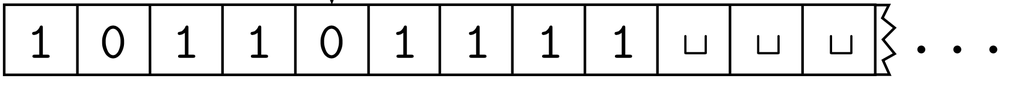

- El cabezal inicia en la celda más a la izquierda del tape

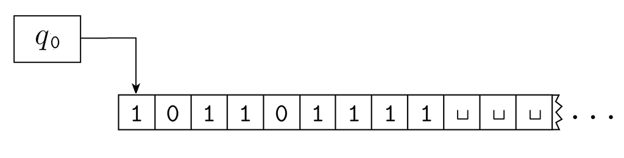

- Nota:
  - El primer blanco marca el fin de $w$
  - Al inicio, si $M$ trata de mover el cabezal a la iquierda, $M$ se queda en el mismo lugar para ese movimeinto, a pesar que $\delta$ indica $L$
- Luego $\delta$ hace todo el trabajo hasta que $M$ entra en $q_a$ o $q_r$, en este punto **PARA** (*HALT*). Si ninguno ocurre, $M$ sigue sin detenerse.

## MÁQUINA DE TURING: COMPUTACIÓN

- Cuando $M$ computa, los cambios ocurren en 3 escenarios:
  - Los estados,
  - El contenido de la cinta,
  - La localizacion del cabezal.
- Para fijar estos cambios definimos una configuración de $M$.
- CONFIGURACIÓN
- Sean $q \in Q$; $u,v$ cadenas sobre $\Gamma$:
  - $C=uqv$ es la configuración del estado $q$, el contenido de la cinta $uv$ y la ubicación del cabezal en el primer símbolo de $v$.
- Ejemplo: $C=1011q_701111$ cuando:
  - En la cinta hay $101101111$
  - El estado es $q_7$
  - El cabezal apuntado al segundo “cero”.

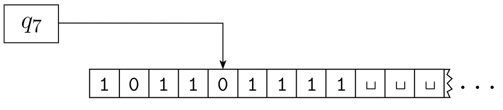

## MÁQUINA DE TURING: COMPUTACIÓN

- PRODUCCIÓN (yield)
- La configuración $C_1$ produce $C_2$ si $M$ se mueve legalmente de $C_1$ a $C_2$ en un solo paso, esto es:
  - Sean los símbolos $a,b,c \in \Gamma$
  - Cadenas $u,v \in \Gamma^*$
  - Estádos $q_i,q_j \in Q$
  - Definimos: $C_1=uaq_ibv$, $C_2=uq_jacv$ y $C_3=uacq_jv$ entoces los movimientos válidos son:
    - LEFT: $C_1=uaq_ibv$ produce $C_2=uq_jacv$
    - si $\delta(q_i,b)=(q_j,c,L)$
    - RIGHT: $C_1=uaq_ibv$ produce $C_3=uacq_jv$
    - si $\delta(q_i,b)=(q_j,c,R)$
- Casos Especiales: Cuando el Cabezal se encuentra en uno de los extremos de la configuración.
  - Para el extremo IZQUIERDO:
    - $q_ibv$ produce $q_jcv$, si $\delta$ se mueve a la **izquiera** (por que se impide que $M$ se salga del extremo izquierdo de la cinta).
    - $q_ibv$ produce $cq_jv$, si $\delta$ se mueve a la **derecha**.
  - Para el extremo DERECHO:
    - $uaq_i$ es equivalente $uaq_i\sqcup$ por que los espacios en blanco siguen la parte de la cinta representada en la configuración.
    - $uaq_i\sqcup$ produce $uq_jac\sqcup$, si $\delta$ se mueve a la **izquiera**.
    - $uaq_i\sqcup$ produce $uacq_j\sqcup$, si $\delta$ se mueve a la **derecha**.

## MÁQUINA DE TURING: COMPUTACIÓN

- La CONFIGURACIÓN INICIAL de $M$ en la entrada $w$ es: $q_0w$, $M$ está en $q_0$ y el cabezal en la posición más a la izquierda de la cinta.
- CONFIGURACIÓN DE ACEPTACIÓN el estado es $q_a$
- CONFIGURACIÓN DE RECHAZO el estado es $q_r$
- Las configuraciones de aceptación y rechazo son CONFIGURACIÓN DE PARADA, y no producen más configuraciones.

## MÁQUINA DE TURING: COMPUTACIÓN

- COMPUTACIÓN:
- Una Máquina de Turing $M$ **acepta** la cadena $w$, si existe una secuencia de configuraciones $C_1,C_2,...,C_k$ donde:
  1. $C_1$ es una configuración inicial de $M$ sobre el input $w$,
  2. Cada $C_i$ produce $C_{i+1}$ y
  3. $C_k$ es una configuración de aceptación.
- La colección de cadenas que $M$ acepta es el **Lenguaje** de $M$
- $L(M)=\{ w|M\mbox{ acepta }\ w\}$ lenguaje **reconocido** por $M$
- DEFINICIÓN: Los lenguajes reconocidos por una máquina de Turing se llaman `Lenguajes Turing Reconocibles` (Lenguajes recursivamente enumerables).
- En resumen, cuando $M$ computa $w$, hay tres posibles resultados: ACEPTA, RECHAZA o entra en un BUCLE.
- Las máquinas que nunca entran en bucles se denominan **DECISORES**, ya que siempre toman la decisión de aceptar o rechazar.
- DEFINICIÓN: Se dice que un `lenguaje es Turing Decidible`, o simplemente **DECIDIBLE**, si alguna máquina de Turing lo decide.
- Todo lenguaje Decidible es Reconocible

## MÁQUINA DE TURING

EJERCICIOS: recordar $M_1$

$\begin{array}{r|*3c} \delta & 0 & 1 & \sqcup\\ \hline \rightarrow s_0 & (s_0,0,R) & (s_1,1,R) & (s_2,\sqcup,R) \\ s_1 & (s_0,0,L) & (s_2,0,L) & (s_3,\sqcup,R) \\ s_2 & -- & -- & -- \\ *s_3 & -- & -- & -- \\ \end{array}$

- Muestre la secuencia de configuraciones al ejecutar $M_1$ con las cadenas:
- $\epsilon, 0,1,01,10,11,00, 001, 010,100$.
- En cada caso indique si la cadena es aceptada, rechazada o bucle.

## MÁQUINA DE TURING

Considere la siguiente M.T.

$\begin{array}{r|*3c} \delta & 0 & 1 & \sqcup \\ \hline \rightarrow s_0 & (s_0,1,R) & (s_0,1,R) & (s_1,\sqcup,L) \\ s_1 & -- & (s_2,1,R) & (s_3,\sqcup,L) \\ *s_2 & -- & -- & -- \\ s_3 & -- & -- & -- \\ \end{array}$

- Muestre la secuencia de configuraciones al ejecutar la M.T. con las cadenas:
- $0111, 111, 11, \epsilon$.
- En cada caso indique si la cadena es aceptada o no.

## MÁQUINA DE TURING

Considere la siguiente M.T.

$\begin{array}{r|*3c} & 0 & 1 & \sqcup \\ \hline \rightarrow s_0 & (s_1,1,R) & (s_1,0,R) & (s_1,0,R) \\ s_1 & (s_2,1,L) & (s_1,0,R) & (s_2,0,L) \\ *s_2 & -- & -- & -- \\ \end{array}$

- Muestre la secuencia de configuraciones al ejecutar la M.T. con las cadenas:
- $0111, 101, 11, ε$.
- En cada caso indique si la cadena es aceptada o no.
- Para simplificar la M.T., No se muestra el estado de rechazo (puede estar implícito).

## CONCLUSIONES

### En esta sesión aprendiste

- La máquina de Turing
- El concepto de Configuración
- La Computación de una maquina de Turing.
- El lenguaje que Reconoce y Decide.